# My Journey with Sleep: Powered by WHOOP

```r
Sys.setenv(RETICULATE_PYTHON = "/home/tliggett/.pyenv/versions/3.9.4/bin/python3.9")
library(reticulate)
```

```python
reticulate::repl_python()
```

```
Error in `$.python.builtin.object`(x, name) :
  promise already under evaluation: recursive default argument reference or earlier problems?
Python 3.9.4 (/home/tliggett/.pyenv/versions/3.9.4/bin/python3.9)
Reticulate 1.19 REPL -- A Python interpreter in R.
```

```python
import requests  # for getting URL
import json  # for parsing json
from datetime import datetime  # datetime parsing
import pytz  # timezone adjusting
import csv  # for making csv files
import os
import pandas as pd
import numpy as np

save_directory = "~/workspace/coursework/data_visualization__COSC322/final_project" # keep trailing slash
```

This is where the API requests from WHOOP are made.

```python
def get_user_data_raw(username: str, password: str, start_date='2000-01-01T00:00:00.000Z', end_date='2030-01-01T00:00:00.000Z', url='https://api-7.whoop.com/users/{}/cycles'):

  #################################################################
  # GET ACCESS TOKEN
  # Post credentials
  r = requests.post("https://api-7.whoop.com/oauth/token", json={
  "grant_type": "password",
  "issueRefresh": False,
  "password": password,
  "username": username })

  # Exit if fail
  if r.status_code != 200:
    print("Fail - Credentials rejected.")
    return 1

  print("Success - Credentials accepted")

  # Set userid/token variables
  userid = r.json()['user']['id']
  access_token = r.json()['access_token']

  # GET DATA
  # Download data
  url = url.format(userid)

  params = {
  'start': start_date,
  'end': end_date
  }

  headers = {
  'Authorization': 'bearer {}'.format(access_token)
  }
  r = requests.get(url, params=params, headers=headers)

  # Check if user/auth are accepted
  if r.status_code != 200:
    print("Fail - User ID / auth token rejected.")
    return 1

  print("Success - User ID / auth token accepted")
  # print(json.dumps(r.json()))
  data_raw = r.json()
  return data_raw


def get_user_data_df(username: str,
                       password: str,
                       start_date='2000-01-01T00:00:00.000Z',
                       end_date='2030-01-01T00:00:00.000Z',
                       url='https://api-7.whoop.com/users/{}/cycles'):
  # get raw whoop data
  data_raw = get_user_data_raw(username, password, start_date, end_date, url)
  # convert json to pandas df

  # df = pd.DataFrame.from_dict(data_raw)
  df = pd.json_normalize(data_raw)
  return df
```

```python
tj_data = get_user_data_df("trevor.liggett@gmail.com", "StrongestHalls43")
```

```
Success - Credentials accepted
Success - User ID / auth token accepted
```

```python
izzy_data = get_user_data_df("sommersizzy@gmail.com", "ilovetj")
```

```
Success - Credentials accepted
Success - User ID / auth token accepted
```

This data wrangling is necessary to get both the dates and many of the sleep statistics formatted correctly.

```python
def first_date(row):
  return row['days'][0]

tj_data['date'] = tj_data.apply (lambda row: first_date(row), axis=1)
```

```python
def get_sleep_stat(row, sleep_stat: str):
  if row['sleep.sleeps'] == []:
    return np.nan
  return row['sleep.sleeps'][0][sleep_stat]

tj_data['sleep.sws.duration'] = tj_data.apply (lambda row: get_sleep_stat(row, 'slowWaveSleepDuration'), axis=1)
tj_data['sleep.quality.duration'] = tj_data.apply (lambda row: get_sleep_stat(row, 'qualityDuration'), axis=1)
tj_data['sleep.light.duration'] = tj_data.apply (lambda row: get_sleep_stat(row, 'lightSleepDuration'), axis=1)
tj_data['sleep.rem.duration'] = tj_data.apply (lambda row: get_sleep_stat(row, 'remSleepDuration'), axis=1)
tj_data['sleep.wake.duration'] = tj_data.apply (lambda row: get_sleep_stat(row, 'wakeDuration'), axis=1)
tj_data['respiratoryRate'] = tj_data.apply (lambda row: get_sleep_stat(row, 'respiratoryRate'), axis=1)
tj_data['sleep.efficiency'] = tj_data.apply (lambda row: get_sleep_stat(row, 'sleepEfficiency'), axis=1)
tj_data['sleep.consistency'] = tj_data.apply (lambda row: get_sleep_stat(row, 'sleepConsistency'), axis=1)
```

```r
quit
library(ggplot2)
library(tidyverse)
library(lubridate)
library(patchwork) # To display 2 charts together
```

```r
tj_data <- py$tj_data
tj_data$date <- as.Date(tj_data$date, format = "%Y-%m-%d")
```

### SLEEP

These graphs display summaries of how much time I spent in the different stages of sleep.

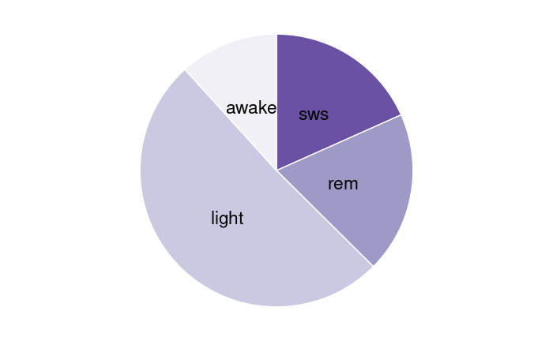

```r
labels <- c("sws", "rem", "light", "awake")

sleep_stats <- tj_data %>%
  # filter(!is.na(as.numeric(sleep.sws.duration))) %>%
  summarize(sws = mean(sleep.sws.duration, na.rm = TRUE) / 3600000,
          rem = mean(sleep.rem.duration, na.rm = TRUE) / 3600000,
          light = mean(sleep.light.duration, na.rm = TRUE) / 3600000,
          wake = mean(sleep.wake.duration, na.rm = TRUE) / 3600000)
# Create Data
data <- data.frame(
  group=c("sws", "rem", "light", "awake"),
  value=c(sleep_stats$sws, sleep_stats$rem, sleep_stats$light, sleep_stats$wake)
)


# Compute the position of labels
data <- data %>%
  arrange(desc(group)) %>%
  mutate(prop = value / sum(data$value) *100) %>%
  mutate(ypos = cumsum(prop)- 0.5*prop )

# Basic piechart
ggplot(data, aes(x="", y=prop, fill=group)) +
  geom_bar(stat="identity", width=1, color="white") +
  coord_polar("y", start=0) +
  theme_void() +
  theme(legend.position="none") +
  geom_text(aes(y = ypos, label = group), color = "black", size=6) +
  scale_fill_brewer(palette="Purples")
```

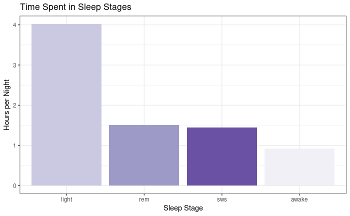

```r
# Bar chart version
ggplot(data = data) +
    geom_bar(stat = "identity", mapping = aes(x=reorder(group, -value), y = value, fill=group)) +
    labs(title = "Time Spent in Sleep Stages", x="Sleep Stage", y="Hours per Night") +
    theme_bw() +
    theme(legend.position = "none") +
    scale_fill_brewer(palette="Purples")
```

### STRAIN

Here I wrangled the workout data from both me and Izzy in python.

```python
reticulate::repl_python()
```

```
Python 3.9.4 (/home/tliggett/.pyenv/versions/3.9.4/bin/python3.9)
Reticulate 1.19 REPL -- A Python interpreter in R.
```

```python
workouts = pd.DataFrame(columns=['sportId', 'cumulativeWorkoutStrain', 'score'])

for row in tj_data['strain.workouts']:
  for workout in row:
    workouts = workouts.append({'sportId': workout['sportId'],
                                'cumulativeWorkoutStrain': workout['cumulativeWorkoutStrain'],
                                'score': workout['score']
                                }, ignore_index=True)


izzy_workouts = pd.DataFrame(columns=['sportId', 'cumulativeWorkoutStrain', 'score'])

for row in izzy_data['strain.workouts']:
  for workout in row:
    izzy_workouts = izzy_workouts.append({'sportId': workout['sportId'],
                                'cumulativeWorkoutStrain': workout['cumulativeWorkoutStrain'],
                                'score': workout['score']
                                }, ignore_index=True)
```

Now to convert and pipe the data into meaningful summaries, and then graph the findings. Done in R

[figure not shown]

```r
workouts <- py$workouts  %>%
  filter(sportId %in% c(21, 0, 98, 39, 45, 44)) %>%
  group_by(sportId) %>%
  summarize(strain = mean(score, na.rm = TRUE)) %>%
  arrange(desc(strain))

izzy_workouts <- py$izzy_workouts  %>%
  filter(sportId %in% c(0, 36, 87)) %>%
  group_by(sportId) %>%
  summarize(strain = mean(score, na.rm = TRUE)) %>%
  arrange(desc(strain))

workouts$sport <- c("Football", "Running", "Jiu Jitsu", "Boxing", "Weightlifting", "Yoga")

izzy_workouts$sport <- c("Running",  "Volleyball", "Coaching")

ggplot(data = workouts) +
    geom_bar(stat = "identity", mapping = aes(x=reorder(sport, -strain), y = strain, fill=reorder(sport, -strain))) +
    labs(title = "Average Strain by Activity for T.J.", x="Activity", y="Average WHOOP Strain") +
    theme_bw() +
    theme(legend.position = "none") +
    scale_fill_brewer(palette="Oranges")
```

[figure not shown]

```r
ggplot(data = izzy_workouts) +
    geom_bar(stat = "identity", mapping = aes(x=reorder(sport, -strain), y = strain, fill=reorder(sport, -strain))) +
    labs(title = "Average Strain by Activity for Izzy", x="Activity", y="Average WHOOP Strain") +
    theme_bw() +
    theme(legend.position = "none") +
    scale_fill_brewer(palette="Oranges")
```

### RECOVERY

Charts to show the relationships between recovery statistics.

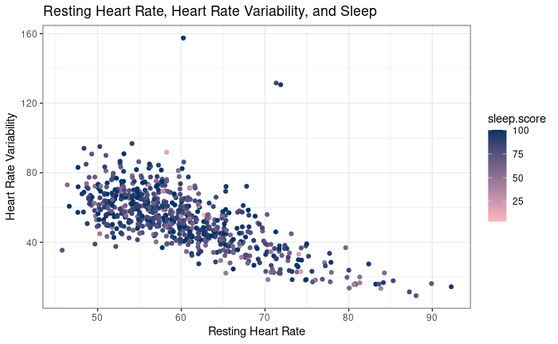

```r
tj_data$recovery.hrv <- tj_data$recovery.heartRateVariabilityRmssd * 1000
tj_data$sleep.hours <- tj_data$sleep.qualityDuration / 3600000

ggplot(data = tj_data, aes(x = recovery.restingHeartRate, y = recovery.hrv, color=sleep.score)) +
  geom_jitter() +
  scale_color_gradient(low="lightpink", high="#003366") +
  labs(title = "Resting Heart Rate, Heart Rate Variability, and Sleep", x="Resting Heart Rate", y="Heart Rate Variability") +
  theme_bw()
```

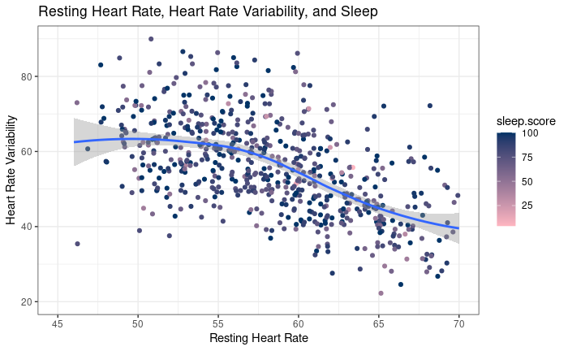

```r
ggplot(data = tj_data, aes(x = recovery.restingHeartRate, y = recovery.hrv, color=sleep.score)) +
  geom_jitter() +
  geom_smooth() +
  scale_color_gradient(low="lightpink", high="#003366") +
  labs(title = "Resting Heart Rate, Heart Rate Variability, and Sleep", x="Resting Heart Rate", y="Heart Rate Variability") +
  theme_bw() +
  xlim(45, 70) + ylim(20, 90)
```

```r
NA
```

## DAY OF WEEK SUMMARIES

The data wrangling for the dow summaries

```r
tj_data$dayOfWeek <- weekdays(as.Date(tj_data$date))
tj_data$dayOfWeekNum <- wday(as.Date(tj_data$date))

weekdays <- c("Sunday", "Monday", "Tuesday", "Wednesday", "Thursday", "Friday", "Saturday")

weekday_data <- tj_data %>%
  group_by(dayOfWeekNum) %>%
  summarize(recovery = median(recovery.score, na.rm = TRUE), strain = median(strain.score, na.rm = TRUE), sleep = mean(sleep.qualityDuration, na.rm = TRUE) / 3600000, sleep_need = mean(sleep.needBreakdown.total, na.rm = TRUE) /3600000)

weekday_data$dow <- weekdays

weekday_data
```

| dayOfWeekNum | recovery | strain | sleep | sleep_need | dow |
| --- | --- | --- | --- | --- | --- |
| 1 | 55 | 6.152754 | 7.171962 | 8.085589 | Sunday |
| 2 | 75 | 12.958233 | 6.960574 | 8.235998 | Monday |
| 3 | 61 | 13.097235 | 6.984664 | 8.546159 | Tuesday |
| 4 | 56 | 12.552008 | 6.901612 | 8.559127 | Wednesday |
| 5 | 58 | 12.930203 | 6.826156 | 8.789615 | Thursday |
| 6 | 57 | 11.712450 | 6.726550 | 8.619979 | Friday |
| 7 | 52 | 8.908119 | 7.360054 | 8.515442 | Saturday |

Pretty graphs to show trends in dow

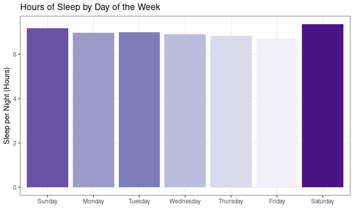

```r
ggplot(data = weekday_data) +
    geom_bar(stat = "identity", mapping = aes(x=reorder(dow,dayOfWeekNum), y = sleep, fill=reorder(dow, sleep))) +
    labs(title = "Hours of Sleep by Day of the Week",x = "", y="Sleep per Night (Hours)") +
    theme_bw() +
    theme(legend.position = "none") +
    scale_fill_brewer(palette="Purples")
```

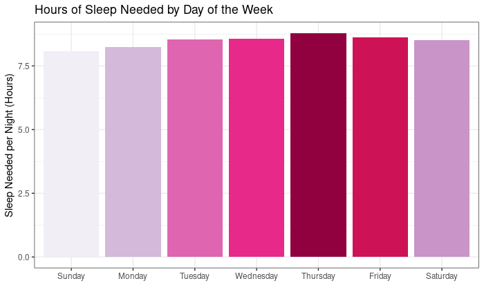

```r
ggplot(data = weekday_data) +
    geom_bar(stat = "identity", mapping = aes(x=reorder(dow,dayOfWeekNum), y = sleep_need, fill=reorder(dow,sleep_need))) +
    labs(title = "Hours of Sleep Needed by Day of the Week",x="", y="Sleep Needed per Night (Hours)") +
    theme_bw() +
    theme(legend.position = "none") +
    scale_fill_brewer(palette="PuRd")
```

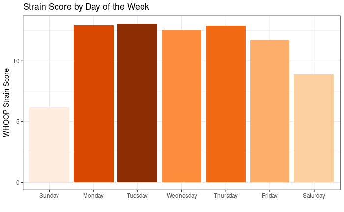

```r
ggplot(data = weekday_data) +
    geom_bar(stat = "identity", mapping = aes(x=reorder(dow,dayOfWeekNum), y = strain, fill=reorder(dow,strain))) +
    labs(title = "Strain Score by Day of the Week", x="", y="WHOOP Strain Score") +
    theme_bw() +
    theme(legend.position = "none") +
    scale_fill_brewer(palette="Oranges")
```

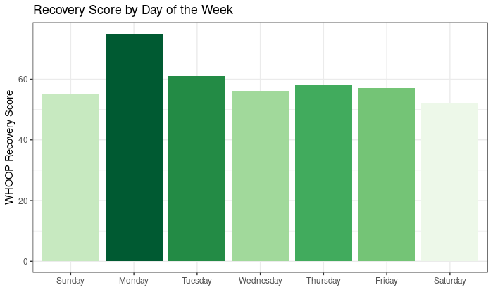

```r
ggplot(data = weekday_data) +
    geom_bar(stat = "identity", mapping = aes(x=reorder(dow,dayOfWeekNum), y = recovery, fill = reorder(dow,recovery))) +
    labs(title = "Recovery Score by Day of the Week", x="", y="WHOOP Recovery Score") +
    theme_bw() +
    theme(legend.position = "none") +
    scale_fill_brewer(palette="Greens")
```

Didn’t end up using this but shows the sleep debt incurred in a typical week

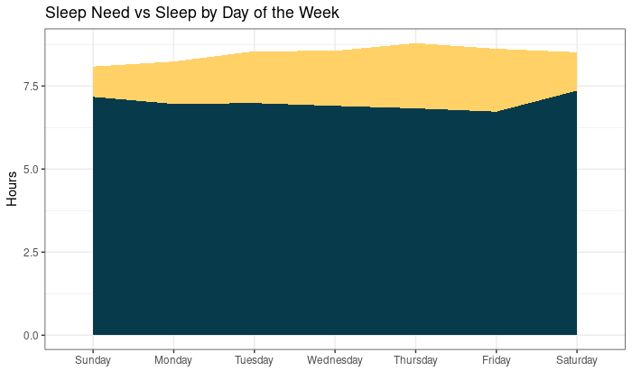

```r
ggplot(data = weekday_data, aes(x=reorder(dow,dayOfWeekNum), group = 1)) +
  geom_area(aes(y=sleep_need), fill="#FFD166") +
  geom_area(aes(y=sleep), fill = "#073B4C") +
  labs(title = "Sleep Need vs Sleep by Day of the Week",x="", y="Hours") +
    theme_bw() +
    theme(legend.position = "none")
```

## MONTHLY SUMMARIES

Summarized data by month. Used in presentation but not the paper.

```r
# The wrangling of the data
months <- c("Jan", "Feb", "Mar", "Apr", "May", "Jun", "Jul", "Aug", "Sep", "Oct", "Nov", "Dec")

tj_data$month <- month(as.Date(tj_data$date))

month_data <- tj_data %>%
  filter(date >= "2020-01-01" & date <"2021-01-01") %>%
  group_by(month) %>%
  summarize(recovery = mean(recovery.score, na.rm = TRUE), strain = mean(strain.score, na.rm = TRUE), sleep = mean(sleep.qualityDuration, na.rm = TRUE) / 3600000, sleep_need = mean(sleep.needBreakdown.total, na.rm = TRUE) /3600000)

month_data$monthtext <- months

month_data
```

| month | recovery | strain | sleep | sleep_need | monthtext |
| --- | --- | --- | --- | --- | --- |
| 1 | 57.89655 | 10.311614 | 6.853161 | 8.623407 | Jan |
| 2 | 60.79310 | 11.564513 | 6.957157 | 9.060672 | Feb |
| 3 | 64.43478 | 9.287099 | 7.089860 | 8.715013 | Mar |
| 4 | 63.46667 | 10.555871 | 7.099221 | 8.544709 | Apr |
| 5 | 56.50000 | 9.943054 | 7.078087 | 8.599903 | May |
| 6 | 57.16667 | 12.440945 | 6.703877 | 8.430310 | Jun |
| 7 | 57.51613 | 11.075592 | 6.613951 | 8.609364 | Jul |
| 8 | 56.65517 | 11.536605 | 7.051709 | 8.700162 | Aug |
| 9 | 58.90000 | 10.154535 | 7.367824 | 7.831096 | Sep |
| 10 | 59.10000 | 11.038353 | 7.497224 | 8.665091 | Oct |

[output cut: 2 more lines]

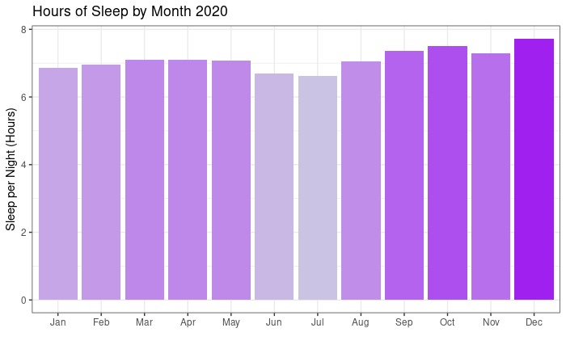

```r
# Pretty graphs

ggplot(data = month_data) +
    geom_bar(stat = "identity", mapping = aes(x=reorder(monthtext, month), y = sleep, fill=sleep)) +
    labs(title = "Hours of Sleep by Month 2020",x = "", y="Sleep per Night (Hours)") +
    theme_bw() +
    theme(legend.position = "none") +
    scale_fill_continuous(low="#CBC3E3", high="purple")
```

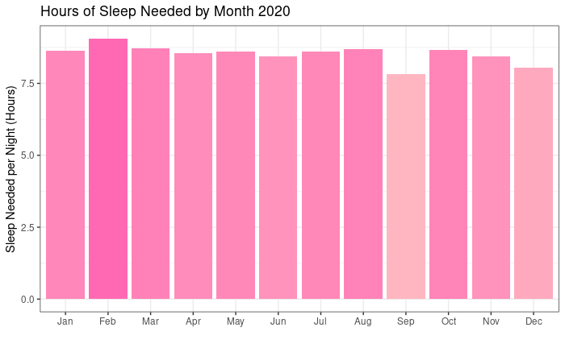

```r
ggplot(data = month_data) +
    geom_bar(stat = "identity", mapping = aes(x=reorder(monthtext, month), y = sleep_need, fill=sleep_need)) +
    labs(title = "Hours of Sleep Needed by Month 2020",x="", y="Sleep Needed per Night (Hours)") +
    theme_bw() +
    theme(legend.position = "none") +
    scale_fill_continuous(low="lightpink", high="hotpink")
```

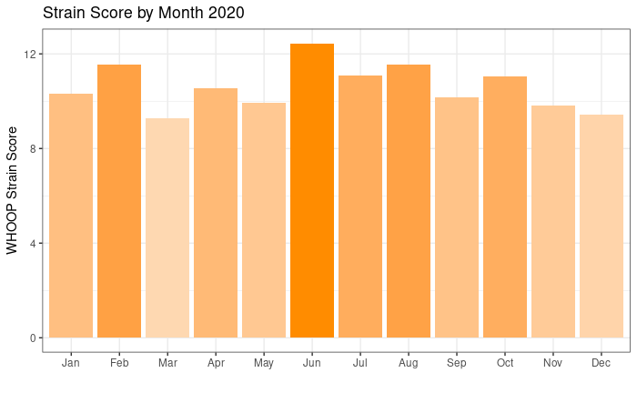

```r
ggplot(data = month_data) +
    geom_bar(stat = "identity", mapping = aes(x=reorder(monthtext, month), y = strain, fill=strain)) +
    labs(title = "Strain Score by Month 2020", x="", y="WHOOP Strain Score") +
    theme_bw() +
    theme(legend.position = "none") +
    scale_fill_continuous(low="#fed8b1", high="darkorange")
```

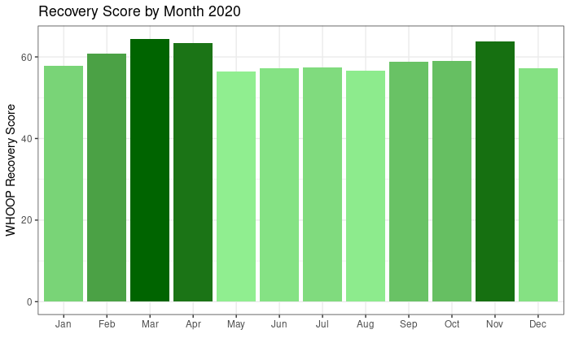

```r
ggplot(data = month_data) +
    geom_bar(stat = "identity", mapping = aes(x=reorder(monthtext, month), y = recovery, fill=recovery)) +
    labs(title = "Recovery Score by Month 2020", x="", y="WHOOP Recovery Score") +
    theme_bw() +
    theme(legend.position = "none") +
    scale_fill_continuous(low="lightgreen", high="darkgreen")
```

## COVID 19 Stuff

For Appendix A. This shows how WHOOP was able to detect my COVID-19 Case as well as my vaccination… Crazy

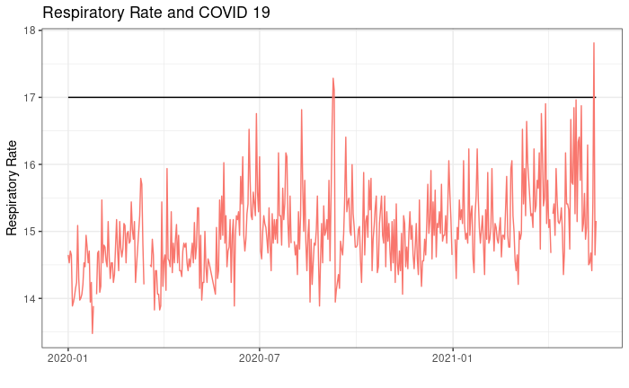

```r
rr_data <- tj_data %>%
  filter(date >= "2020-01-01")

ggplot(data = rr_data, aes(x = date)) +
  geom_line(aes(y=17)) +
  geom_line(aes(y= respiratoryRate, colour='#271033')) +
  labs(title = "Respiratory Rate and COVID 19", x="", y="Respiratory Rate") +
  theme_bw() +
  theme(legend.position = "none")
```

## Weekly Average Summaries

Summarizing some of my major statistics with weekly averages over the years.

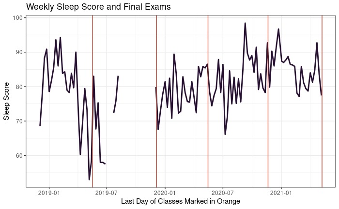

```r
tj_data$week <- week(tj_data$date)
tj_data$year <- year(tj_data$date)

weekly_data <- tj_data %>%
  filter((!(week %in% c(53))) & (date <= '2021-05-13')) %>% # Take out week 53 because it's not full so crazy outliers
  group_by(year, week) %>%
  summarize(sleep = mean(sleep.score, na.rm = TRUE),
            date = min(date, na.rm = TRUE),
            efficiency = mean(sleep.efficiency, na.rm = TRUE),
            consistency = mean(sleep.consistency, na.rm = TRUE),
            duration = mean(sleep.quality.duration, na.rm = TRUE) / 3600000
            )
# These were the last day of classes each of these semesters
finals_dates <- c("2019-05-17","2019-12-05", "2020-05-15","2020-11-20", "2021-05-09")

ggplot(weekly_data, aes(x = date, y = sleep)) +
  geom_line(color="#271033", size = 1) +
  geom_vline(xintercept = as.numeric(as.Date(finals_dates, format = "%Y-%m-%d")), color="#BB4430") +
  labs(title = "Weekly Sleep Score and Final Exams", x="Last Day of Classes Marked in Orange", y="Sleep Score") +
  theme_bw() +
  theme(legend.position = "none")
```

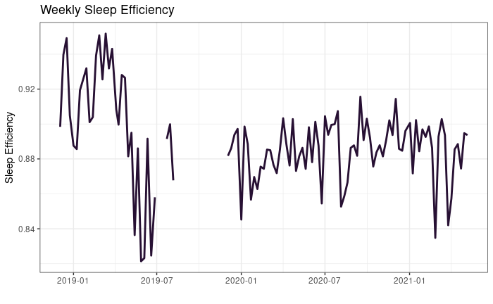

```r
ggplot(weekly_data, aes(x = date, y = efficiency)) +
  geom_line(color="#271033", size = 1) +
  labs(title = "Weekly Sleep Efficiency", x="", y="Sleep Efficiency") +
  theme_bw() +
  theme(legend.position = "none")
```

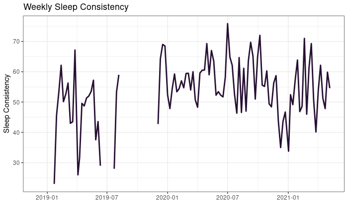

```r
ggplot(weekly_data, aes(x = date, y = consistency)) +
  geom_line(color="#271033", size = 1) +
  labs(title = "Weekly Sleep Consistency", x="", y="Sleep Consistency") +
  theme_bw() +
  theme(legend.position = "none")
```

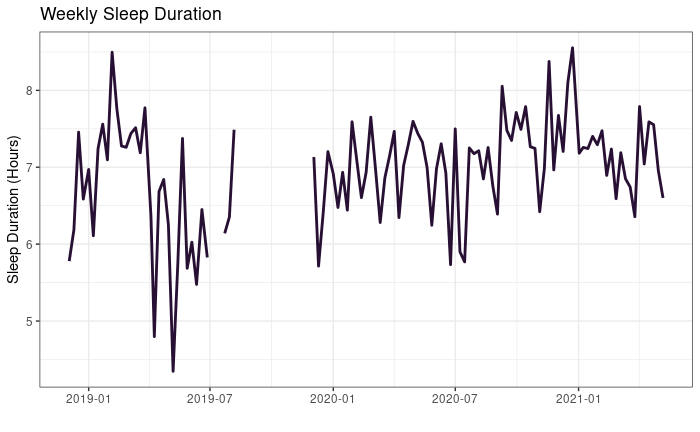

```r
ggplot(weekly_data, aes(x = date, y = duration)) +
  geom_line(color="#271033", size = 1) +
  labs(title = "Weekly Sleep Duration", x="", y="Sleep Duration (Hours)") +
  theme_bw() +
  theme(legend.position = "none")
```